# Task13

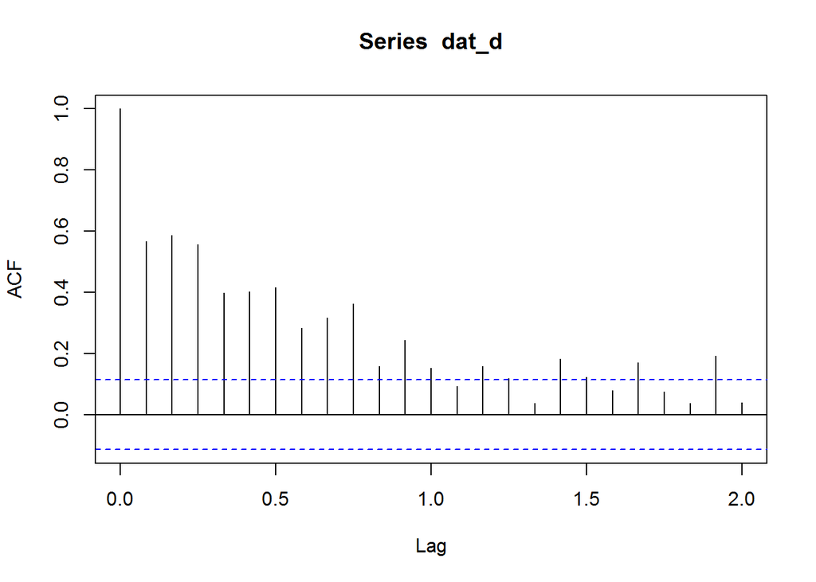

According to graphs, differenced data still seems to be seasonal.

```r
dat_ds<-diff(dat_d, differences = ndiffs(dat_d))
```

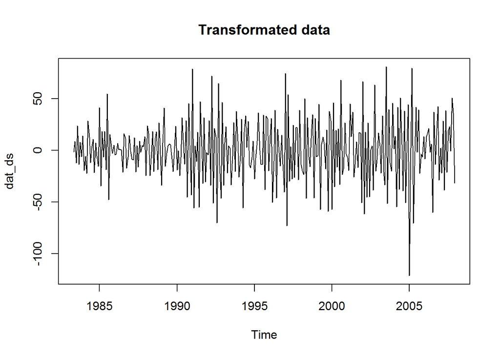

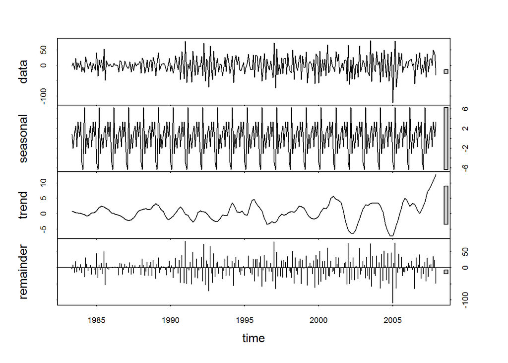

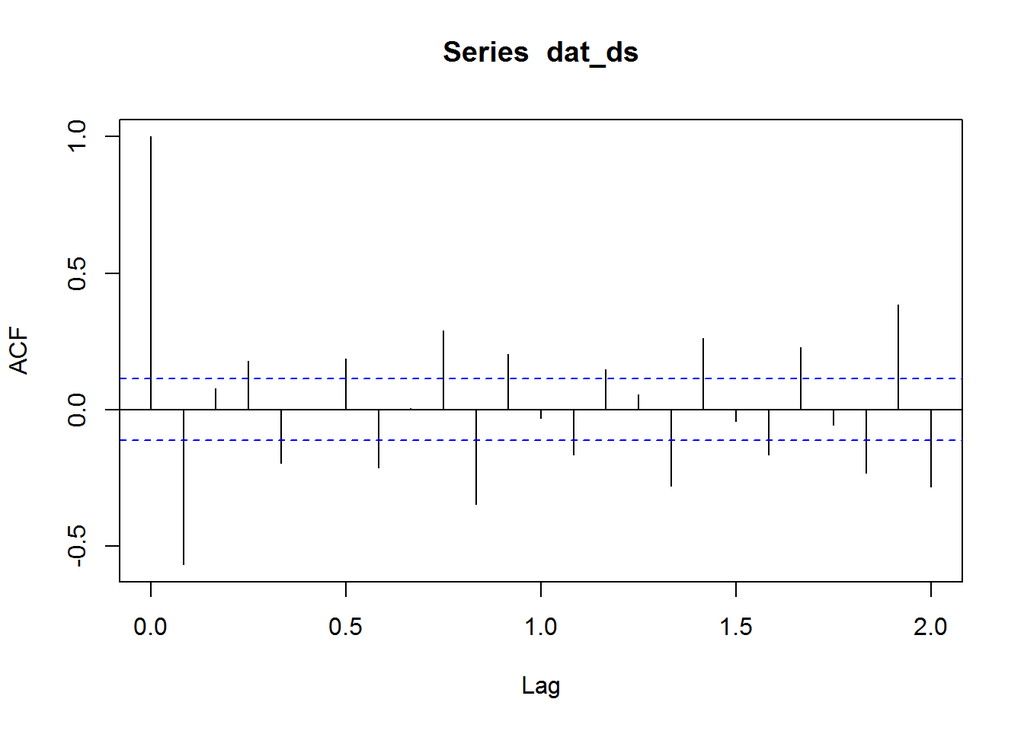

```
##
##  KPSS Test for Level Stationarity
##
## data:  dat_ds
## KPSS Level = 0.0397, Truncation lag parameter = 3, p-value = 0.1
```

```
##
##  Augmented Dickey-Fuller Test
##
## data:  dat_ds
## Dickey-Fuller = -7.0073, Lag order = 6, p-value = 0.01
## alternative hypothesis: stationary
```

After applying seasonal differencing with 1 difference and simple differencing with 1 difference, we are using $adf.test$ to determine if now the data is stationary. Test gives a p-value smaller than 0.05, which means that we can deny null hypothesis and accept that the time series is stationary. Just to make sure the data is stationary, We are using a different test called $kpss.test$. Test gives a p-value higher than 0.05, which means that we cannot deny null hypothesis that the time series is stationary.